[figure not shown]

CL-2

General Description

CLUTCH SYSTEM

1. General Description

A: SPECIFICATION

Model STI Except for STI

Transmission type 6MT 6MT

Clutch cover

Type Pull type Push type

Diaphragm set load N (kgf, lbf) 9,120 (930, 2051) 7,450 (760, 1,675)

Clutch disc

Facing material Woven (non-asbestos)

O.D. × I.D. × Thickness

mm (in)

Clutch

cover side

240 × 160 × 3.5

(9.45 × 6.30 × 0.138)

230 × 155 × 3.5

(9.06 × 6.10 × 0.138)

Flywheel

side

240 × 160 × 3.2

(9.45 × 6.30 × 0.126)

230 × 155 × 3.2

(9.06 × 6.10 × 0.126)

Spline outer diameter mm (in) 25.2 (0.992), (number of teeth: 24)

Depth of rivet head

mm (in)

Clutch

cover side

1.65 — 2.25 (0.065 — 0.089)

Flywheel

side

1.35 — 1.95 (0.053 — 0.077)

Limit of

sinking

0.8 (0.031)

Deflection limit mm (in) 0.7 (0.028) at R = 115 (4.53) 0.7 (0.028) at R = 110 (4.33)

Release bearing Grease-packed self-aligning

Clutch pedal

Full stroke mm (in) 130 — 135 (5.12 — 5.31) 135 — 140 (5.31 — 5.51)

Free play mm (in) 5 — 11 (0.20 — 0.43)

Flywheel Type Conventional Flexible

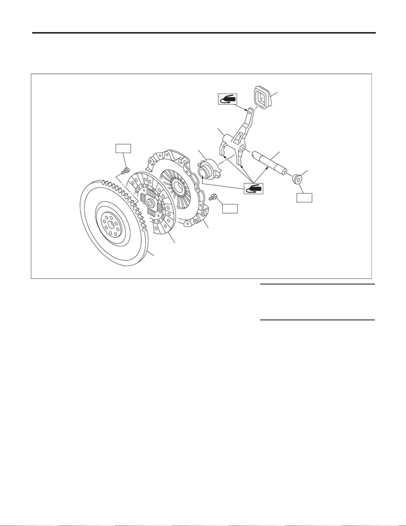

CL-3

General Description

CLUTCH SYSTEM

B: COMPONENT

1. CLUTCH ASSEMBLY

• STI model

(1) Dust cover (5) Release bearing Tightening torque: N·m (kgf-m, ft-lb)

(2) Release lever (6) Clutch cover T1: 16 (1.6, 11.8)

(3) Clutch release lever shaft (7) Clutch disc T2: 48 (4.9, 35.4)

(4) Plug (8) Conventional flywheel T3: 75 (7.6, 55.3)

(1)

(2)

(5)

(3)

(4)

(6)

(7)

(8)

T1

T2

T3

CL-00811

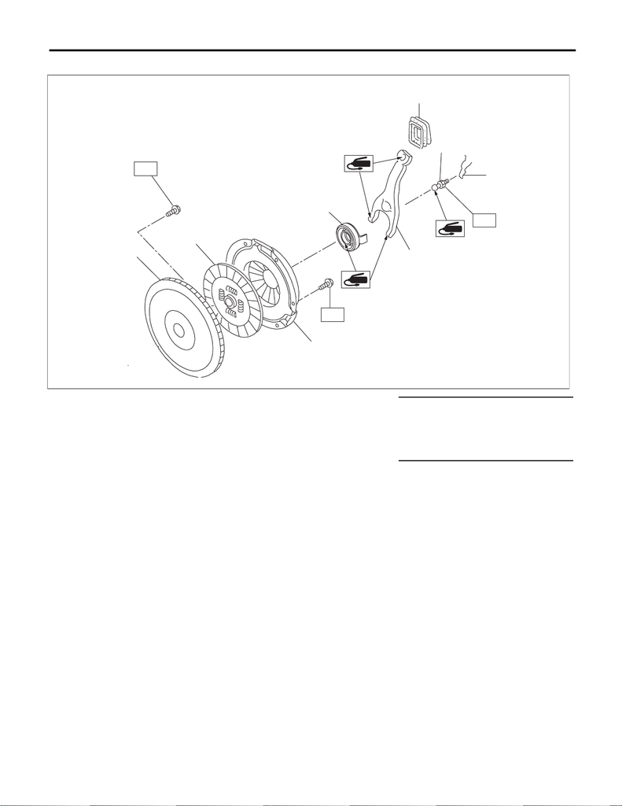

CL-4

General Description

CLUTCH SYSTEM

• Except for STI model

(1) Dust cover (5) Release bearing Tightening torque: N·m (kgf-m, ft-lb)

(2) Lever spring (6) Clutch cover T1: 16 (1.6, 11.8)

(3) Pivot (7) Clutch disc T2: <Ref. to CL-16, EXCEPT FOR

STI MODEL, INSTALLATION,

Flywheel.>

(4) Release lever (8) Flywheel

CL-01034

T1

T1

T2

(1)

(2)

(3)

(4)

(5)

(6)

(7)

(8)

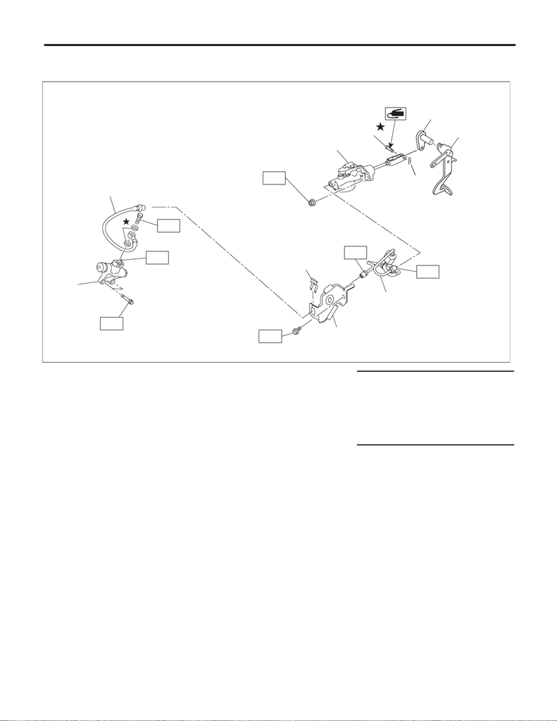

CL-5

General Description

CLUTCH SYSTEM

2. CLUTCH PIPE AND HOSE

• STI model

(1) Operating cylinder (7) Master cylinder ASSY Tightening torque: N·m (kgf-m, ft-lb)

(2) Washer (8) Clevis pin T1: 7.8 (0.8, 5.8)

(3) Clutch hose (9) Lever T2: 15 (1.5, 11.1)

(4) Clip (10) Pedal T3: 18 (1.8, 13.3)

(5) Clutch bracket (11) Snap pin T4: 25 (2.5, 18.4)

(6) Clutch pipe T5: 41 (4.2, 30.2)

CL-01000

(2)

(3)

(1)

T1

T5

T3

(4)

T4

(8)

(7)

(9)

T3

(5)

T2

T2

(11)

(10)

(6)

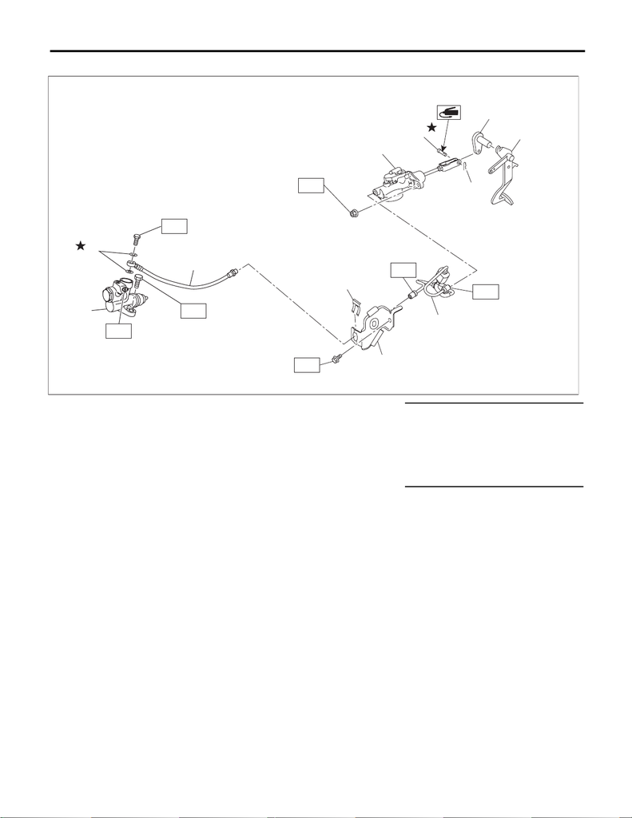

CL-6

General Description

CLUTCH SYSTEM

• Except for STI model

(1) Operating cylinder (7) Master cylinder ASSY Tightening torque: N·m (kgf-m, ft-lb)

(2) Washer (8) Clevis pin T1: 7.8 (0.8, 5.8)

(3) Clutch hose (9) Lever T2: 15 (1.5, 11.1)

(4) Clip (10) Pedal T3: 18 (1.8, 13.3)

(5) Clutch bracket (11) Snap pin T4: 25 (2.5, 18.4)

(6) Clutch pipe T5: 37 (3.8, 27.3)

CL-01001

(4)

T4

(8)

(7)

(9)

T3

(5)

T2

T2

(11)

(10)

(6)

T3

T5

T1

(2)

(3)

(1)

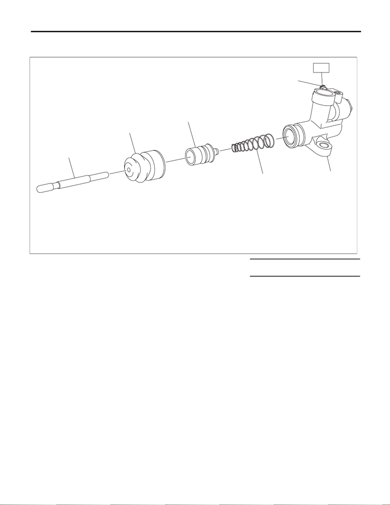

CL-7

General Description

CLUTCH SYSTEM

3. OPERATING CYLINDER

• Except for STI model

(1) Push rod (4) Piston spring Tightening torque: N·m (kgf-m, ft-lb)

(2) Boot (5) Operating cylinder T: 7.8 (0.8, 5.8)

(3) Piston (6) Breather screw

CL-00504

T

(5)

(4)

(3)

(2)

(1)

(6)

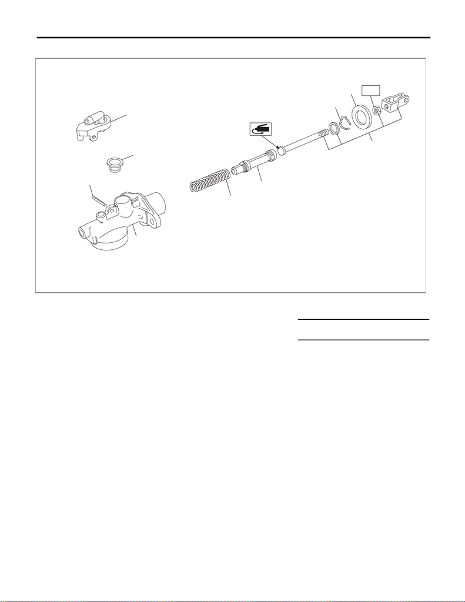

CL-8

General Description

CLUTCH SYSTEM

4. MASTER CYLINDER

(1) Nipple (5) Return spring (9) Seat

(2) Oil seal (6) Piston

(3) Straight pin (7) Push rod ASSY Tightening torque: N·m (kgf-m, ft-lb)

(4) Master cylinder (8) Piston stop ring T: 10 (1.0, 7.4)

CL-01045

(1)

(2)

(3)

(5)

(7)

(6)

(8)

(9)

T

(4)

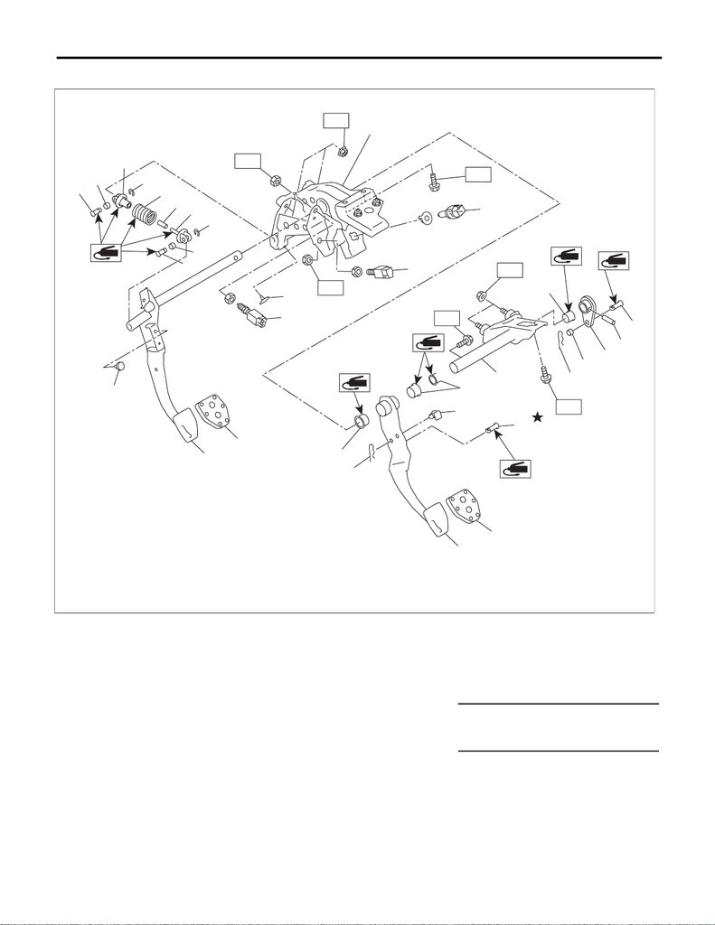

CL-9

General Description

CLUTCH SYSTEM

5. CLUTCH PEDAL

(1) Pedal bracket (10) Assist spring (19) Lever

(2) Stop light switch (11) Assist bushing (20) Snap pin

(3) Clutch switch (12) Assist rod A (21) Brake pedal

(4) Stopper (13) Clutch pedal (22) Brake pedal pad (sport type)

(5) Clutch start switch (14) Clutch pedal pad (sport type)

(6) Clutch clevis pin (15) Bushing Tightening torque: N·m (kgf-m, ft-lb)

(7) Bushing C (16) Clutch master cylinder bracket T1: 8 (0.8, 5.9)

(8) Assist rod B (17) Clevis pin T2: 18 (1.8, 13.3)

(9) Clip (18) Spring pin

CL-01042

(4)

(15)

(4)

(9)(7)

(8)

(10)

(11)

(9)

(12)

(5)

(3)

(1)

(2)

(4)

(17)

(20)

(7)

(18)

(17)

(22)

(21)

(20)

(13)

(14)

(15)

(19)

(16)

(15)

(6)

(7)

(6)

T1

T2

T2

T2

T2

T2

T1

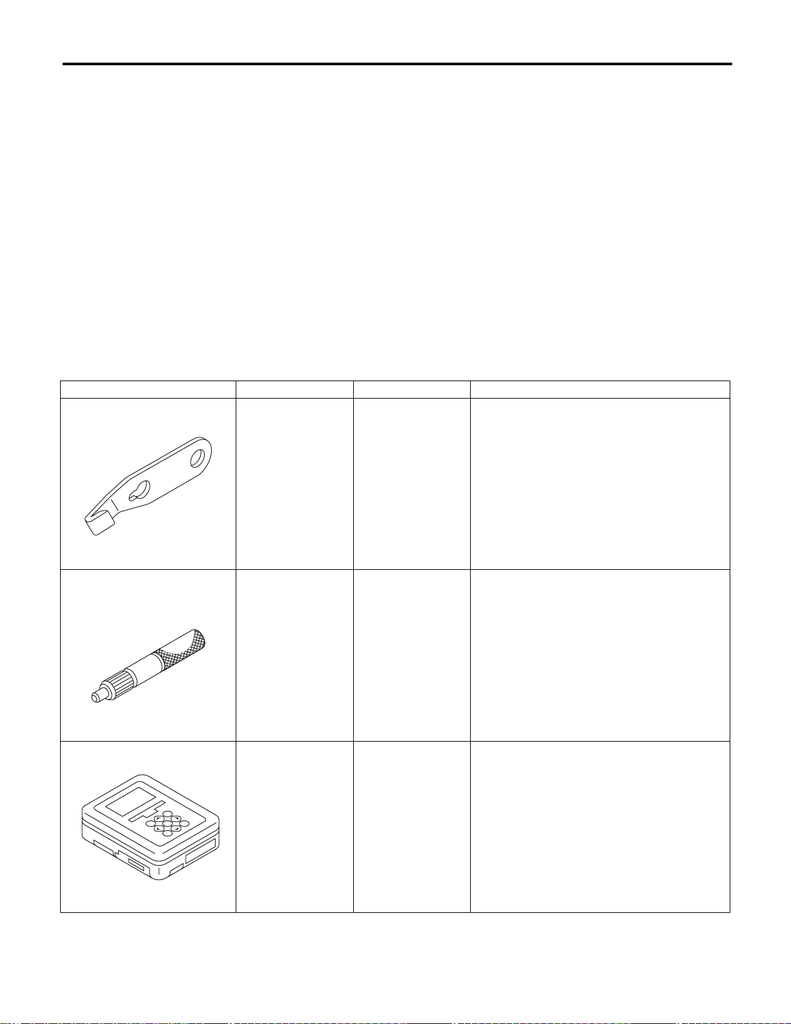

CL-10

General Description

CLUTCH SYSTEM

C: CAUTION

• Remove contamination including dirt and corrosion before removal, installation or disassembly.

• Keep the disassembled parts in order and protect them from dust and dirt.

• Before removal, installation or disassembly, be sure to clarify the failure. Avoid unnecessary removal, in-

stallation, disassembly and replacement.

• Vehicle components are extremely hot after driving. Be wary of receiving burns from heated parts.

• Use SUBARU genuine fluid, grease etc. or equivalent. Do not mix fluid, grease, etc. of different grades or

manufacturers.

• Be sure to tighten fasteners including bolts and nuts to the specified torque.

• Apply grease onto sliding or revolving surfaces before installation.

• Before installing O-rings or snap rings, apply sufficient amount of fluid to avoid damage and deformation.

• Before securing a part in a vise, place cushioning material such as wood blocks, aluminum plate or cloth

between the part and the vise.

• Keep fluid away from the vehicle body. If any fluid contacts the vehicle body, immediately flush the area

with water.

D: PREPARATION TOOL

1. SPECIAL TOOL

ILLUSTRATION TOOL NUMBER DESCRIPTION REMARKS

498497100 CRANKSHAFT

STOPPER

Used for stopping rotation of the flywheel.

499747100 CLUTCH DISC

GUIDE

Used for installing the clutch disc to the flywheel.

1B022XU0 SUBARU SELECT

MONITOR III KIT

Used for installing and adjusting the clutch start

switch.

ST-498497100

ST-499747100

ST1B022XU0

[figure not shown]

CL-11

General Description

CLUTCH SYSTEM

2. GENERAL TOOL

TOOL NAME REMARKS

Circuit tester Used for measuring resistance, voltage and current.

Dial gauge Used for measuring clutch disc run-out.

Depth gauge Used for measuring clutch disc wear.

Angle gauge Used for installing the flywheel.